# NYPD Shooting Incident Data (Historic) Analysis

Jayjit Pradhan

2025-03-30

## Project Purpose

The purpose of this project is to analyze NYPD Shooting Incident Data, a historical list of every shooting incident occurred in NYC, using R.

## Objective

Main objective of this project is to determine whether age and race of victims can be used to predict if a shooting was fatal.

## Load packages

```r
library('tidyverse')
library('lubridate')
library('ggplot2')
```

## Data Description

This is a breakdown of every shooting incident that occurred in NYC going back to 2006 through the end of the previous calendar year. This data is manually extracted every quarter and reviewed by the Office of Management Analysis and Planning before being posted on the NYPD website.

Link: https://catalog.data.gov/dataset/nypd-shooting-incident-data-historic

## Data Load

```r
url <- "https://data.cityofnewyork.us/api/views/833y-fsy8/rows.csv?accessType=DOWNLOAD"
nypd_shootings <- read_csv(url)
glimpse(nypd_shootings) # Glimpse prints every column in a data frame.
```

```
## Rows: 28,562
## Columns: 21
## $ INCIDENT_KEY            <dbl> 231974218, 177934247, 255028563, 25384540, 726…
## $ OCCUR_DATE              <chr> "08/09/2021", "04/07/2018", "12/02/2022", "11/…
## $ OCCUR_TIME              <time> 01:06:00, 19:48:00, 22:57:00, 01:50:00, 01:58…
## $ BORO                    <chr> "BRONX", "BROOKLYN", "BRONX", "BROOKLYN", "BRO…
## $ LOC_OF_OCCUR_DESC       <chr> NA, NA, "OUTSIDE", NA, NA, NA, NA, NA, NA, NA,…
## $ PRECINCT                <dbl> 40, 79, 47, 66, 46, 42, 71, 69, 75, 69, 40, 42…
## $ JURISDICTION_CODE       <dbl> 0, 0, 0, 0, 0, 2, 0, 2, 0, 0, 0, 2, 0, 0, 2, 0…
## $ LOC_CLASSFCTN_DESC      <chr> NA, NA, "STREET", NA, NA, NA, NA, NA, NA, NA, …
## $ LOCATION_DESC           <chr> NA, NA, "GROCERY/BODEGA", "PVT HOUSE", "MULTI …
## $ STATISTICAL_MURDER_FLAG <lgl> FALSE, TRUE, FALSE, TRUE, TRUE, FALSE, TRUE, F…
## $ PERP_AGE_GROUP          <chr> NA, "25-44", "(null)", "UNKNOWN", "25-44", "18…
## $ PERP_SEX                <chr> NA, "M", "(null)", "U", "M", "M", NA, NA, "M",…
## $ PERP_RACE               <chr> NA, "WHITE HISPANIC", "(null)", "UNKNOWN", "BL…
## $ VIC_AGE_GROUP           <chr> "18-24", "25-44", "25-44", "18-24", "<18", "18…
## $ VIC_SEX                 <chr> "M", "M", "M", "M", "F", "M", "M", "M", "M", "…
## $ VIC_RACE                <chr> "BLACK", "BLACK", "BLACK", "BLACK", "BLACK", "…
## $ X_COORD_CD              <dbl> 1006343.0, 1000082.9, 1020691.0, 985107.3, 100…
## $ Y_COORD_CD              <dbl> 234270.0, 189064.7, 257125.0, 173349.8, 247502…
## $ Latitude                <dbl> 40.80967, 40.68561, 40.87235, 40.64249, 40.845…
## $ Longitude               <dbl> -73.92019, -73.94291, -73.86823, -73.99691, -7…
## $ Lon_Lat                 <chr> "POINT (-73.92019278899994 40.80967347200004)"…
```

## Tidy and Transform Data

### Remove Unnecessary Columns

Removing columns not required for this project: INCIDENT_KEY, BORO, LOC_OF_OCCUR_DESC, PRECINCT, JURISDICTION_CODE, LOC_CLASSFCTN_DESC, LOCATION_DESC, PERP_AGE_GROUP, PERP_SEX, PERP_RACE, VIC_SEX, X_COORD_CD, Y_COORD_CD, Latitude, Longitude, Lon_Lat.

```r
nypd_shootings <- nypd_shootings %>% select(-c(
                      INCIDENT_KEY,
                      BORO,
                      LOC_OF_OCCUR_DESC,
                      PRECINCT,
                      JURISDICTION_CODE,
                      LOC_CLASSFCTN_DESC,
                      LOCATION_DESC,
                      PERP_AGE_GROUP,
                      PERP_SEX,
                      PERP_RACE,
                      VIC_SEX,
                      X_COORD_CD,
                      Y_COORD_CD,
                      Latitude,
                      Longitude,
                      Lon_Lat
                      ))
glimpse(nypd_shootings)
```

```
## Rows: 28,562
## Columns: 5
## $ OCCUR_DATE              <chr> "08/09/2021", "04/07/2018", "12/02/2022", "11/…
## $ OCCUR_TIME              <time> 01:06:00, 19:48:00, 22:57:00, 01:50:00, 01:58…
## $ STATISTICAL_MURDER_FLAG <lgl> FALSE, TRUE, FALSE, TRUE, TRUE, FALSE, TRUE, F…
## $ VIC_AGE_GROUP           <chr> "18-24", "25-44", "25-44", "18-24", "<18", "18…
## $ VIC_RACE                <chr> "BLACK", "BLACK", "BLACK", "BLACK", "BLACK", "…
```

### Convert Data Types and create new column

1. Convert OCCUR_DATE to **date object**.
2. Create OCCUR_DATE_TIME column by merging OCCUR_DATE & OCCUR_TIME columns.
3. Drop OCCUR_DATE & OCCUR_TIME columns.

```r
nypd_shootings <- nypd_shootings %>%
  mutate(OCCUR_DATE = mdy(OCCUR_DATE),
         OCCUR_DATE_TIME = paste(OCCUR_DATE, OCCUR_TIME))

nypd_shootings <- nypd_shootings %>% select(-c(
                      OCCUR_DATE,
                      OCCUR_TIME
                      ))
glimpse(nypd_shootings)
```

```
## Rows: 28,562
## Columns: 4
## $ STATISTICAL_MURDER_FLAG <lgl> FALSE, TRUE, FALSE, TRUE, TRUE, FALSE, TRUE, F…
## $ VIC_AGE_GROUP           <chr> "18-24", "25-44", "25-44", "18-24", "<18", "18…
## $ VIC_RACE                <chr> "BLACK", "BLACK", "BLACK", "BLACK", "BLACK", "…
## $ OCCUR_DATE_TIME         <chr> "2021-08-09 01:06:00", "2018-04-07 19:48:00", …
```

### Missing Data

```r
# Identify columns with missing data and display the number of missing values per column.
colSums(is.na(nypd_shootings))
```

```
## STATISTICAL_MURDER_FLAG           VIC_AGE_GROUP                VIC_RACE
##                       0                       0                       0
##         OCCUR_DATE_TIME
##                       0
```

**Observation:** No data is missing for required columns.

## Data Summary

```r
summary(nypd_shootings)
```

```
##  STATISTICAL_MURDER_FLAG VIC_AGE_GROUP        VIC_RACE
##  Mode :logical           Length:28562       Length:28562
##  FALSE:23036             Class :character   Class :character
##  TRUE :5526              Mode  :character   Mode  :character
##  OCCUR_DATE_TIME
##  Length:28562
##  Class :character
##  Mode  :character
```

## Visualizations and Analysis

### Fatal Shootings

The variable **STATISTICAL_MURDER_FLAG** indicates whether a shooting was non-fatal **FALSE** or fatal **TRUE**.

```r
table(nypd_shootings$STATISTICAL_MURDER_FLAG)
```

```
##
## FALSE  TRUE
## 23036  5526
```

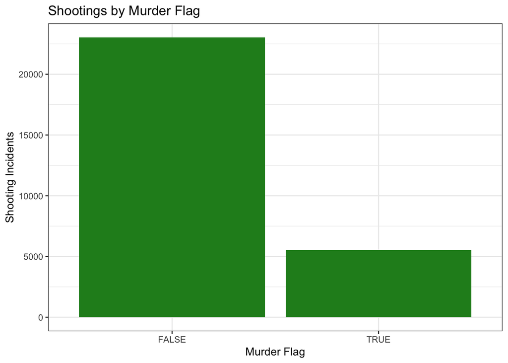

```r
nypd_shootings %>%
  ggplot(aes(x = STATISTICAL_MURDER_FLAG)) +
  geom_bar(fill = "#228B22")+
  theme_bw()+
  labs(x = "Murder Flag",
       y = "Shooting Incidents",
       title = "Shootings by Murder Flag")
```

**Observation:** Data contains 23,036 non-fatal shootings and 5,526 fatal shootings.

### Victim Age

Below tables show counts of shootings in each age group and also categories by non-fatal and fatal.

```r
table(nypd_shootings$VIC_AGE_GROUP)
```

```
##
##     <18    1022   18-24   25-44   45-64     65+ UNKNOWN
##    2954       1   10384   12973    1981     205      64
```

```r
table(nypd_shootings$STATISTICAL_MURDER_FLAG, nypd_shootings$VIC_AGE_GROUP)
```

```
##
##           <18  1022 18-24 25-44 45-64   65+ UNKNOWN
##   FALSE  2569     1  8654 10135  1489   139      49
##   TRUE    385     0  1730  2838   492    66      15
```

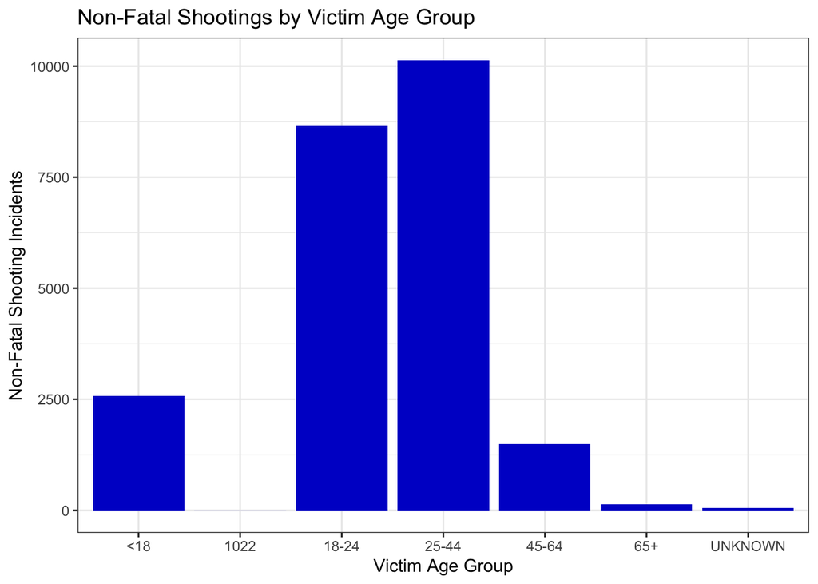

```r
nypd_shootings %>%
  filter(STATISTICAL_MURDER_FLAG == FALSE) %>%
  ggplot(aes(x = VIC_AGE_GROUP)) +
  geom_bar(fill = "#0000CD")+
  theme_bw()+
  labs(x = "Victim Age Group",
       y = "Non-Fatal Shooting Incidents",
       title = "Non-Fatal Shootings by Victim Age Group")
```

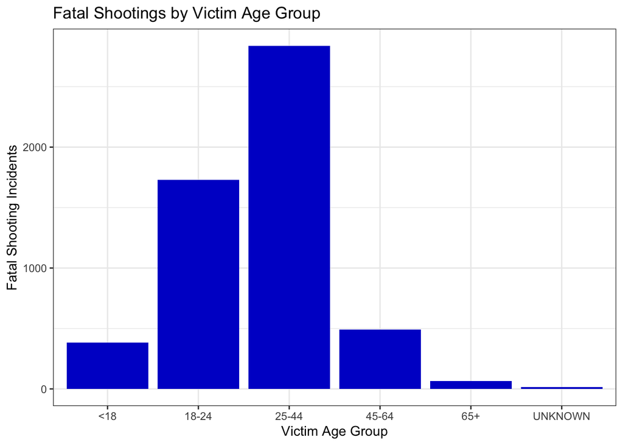

```r
nypd_shootings %>%
  filter(STATISTICAL_MURDER_FLAG == TRUE) %>%
  ggplot(aes(x = VIC_AGE_GROUP)) +
  geom_bar(fill = "#0000CD")+
  theme_bw()+
  labs(x = "Victim Age Group",
       y = "Fatal Shooting Incidents",
       title = "Fatal Shootings by Victim Age Group")
```

**Observation:** 1. Majority of victims of both fatal and non-fatal shootings are in the 18-24 and 25-44 age groups. 2. From the bar charts, it is evident that Age groups can be an important factor in determining fatal and non-fatal shootings.

### Victim Race

Below tables show counts of shootings in each race and also categories by non-fatal and fatal.

```r
table(nypd_shootings$VIC_RACE)
```

```
##
## AMERICAN INDIAN/ALASKAN NATIVE       ASIAN / PACIFIC ISLANDER
##                             11                            440
##                          BLACK                 BLACK HISPANIC
##                          20235                           2795
##                        UNKNOWN                          WHITE
##                             70                            728
##                 WHITE HISPANIC
##                           4283
```

```r
table(nypd_shootings$STATISTICAL_MURDER_FLAG, nypd_shootings$VIC_RACE)
```

```
##
##         AMERICAN INDIAN/ALASKAN NATIVE ASIAN / PACIFIC ISLANDER BLACK
##   FALSE                             11                      330 16384
##   TRUE                               0                      110  3851
##
##         BLACK HISPANIC UNKNOWN WHITE WHITE HISPANIC
##   FALSE           2332      63   532           3384
##   TRUE             463       7   196            899
```

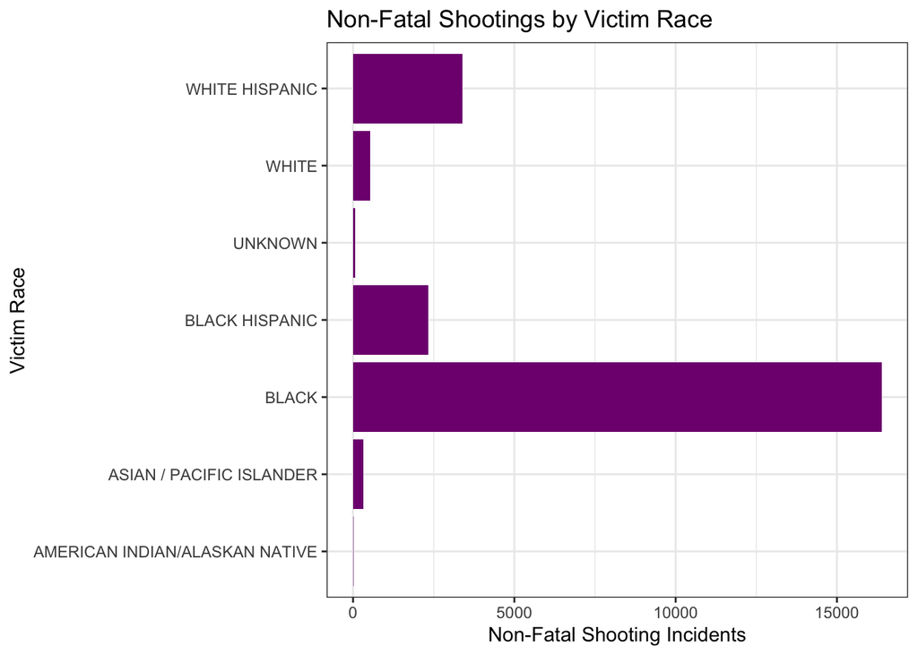

```r
nypd_shootings %>%
  filter(STATISTICAL_MURDER_FLAG == FALSE) %>%
  ggplot(aes(x = VIC_RACE)) +
  geom_bar(fill = "#800080")+
  coord_flip()+
  theme_bw()+
  labs(x = "Victim Race",
       y = "Non-Fatal Shooting Incidents",
       title = "Non-Fatal Shootings by Victim Race")
```

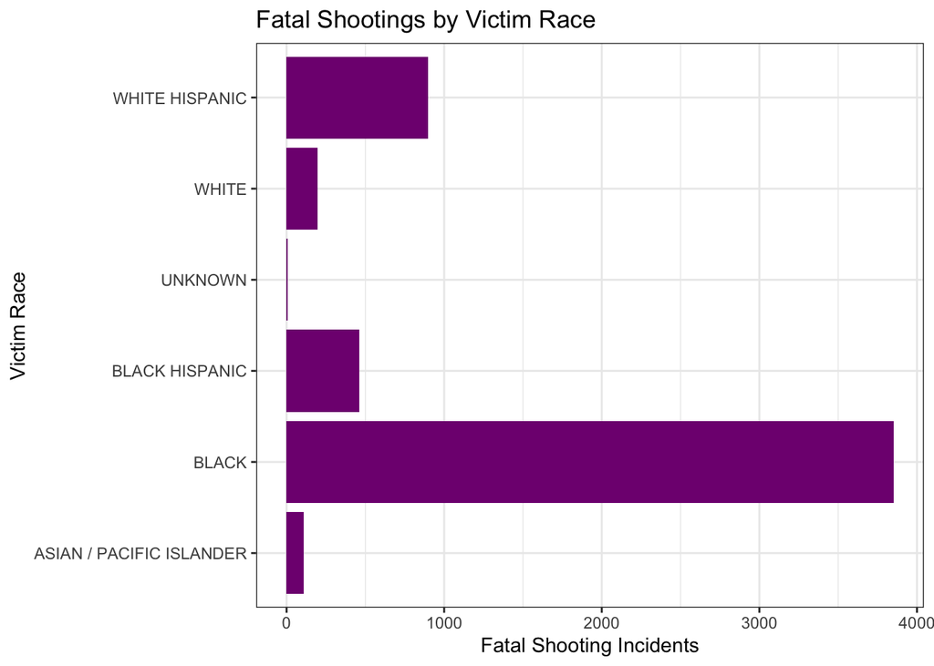

```r
nypd_shootings %>%
  filter(STATISTICAL_MURDER_FLAG == TRUE) %>%
  ggplot(aes(x = VIC_RACE)) +
  geom_bar(fill = "#800080")+
  coord_flip()+
  theme_bw()+
  labs(x = "Victim Race",
       y = "Fatal Shooting Incidents",
       title = "Fatal Shootings by Victim Race")
```

**Observation:** 1. Majority of victims of both fatal and non-fatal shootings are Black, followed by Hispanics. 2. From the bar charts, it is evident that Victim Race can be an important factor in determining fatal and non-fatal shootings.

## Regression Model

Logistic Regression model was used to determine whether victim’s age and race can be used to predict if a shooting is fatal.

**Predictive Variable:** STATISTICAL_MURDER_FLAG

**Dependent Variables:** VIC_AGE_GROUP, VIC_RACE

```r
logistic_model <- glm(STATISTICAL_MURDER_FLAG ~ VIC_AGE_GROUP + VIC_RACE, data = nypd_shootings, family = 'binomial')
summary(logistic_model)
```

```
##
## Call:
## glm(formula = STATISTICAL_MURDER_FLAG ~ VIC_AGE_GROUP + VIC_RACE,
##     family = "binomial", data = nypd_shootings)
##
## Coefficients:
##                                   Estimate Std. Error z value Pr(>|z|)
## (Intercept)                      -12.93121   97.41223  -0.133  0.89439
## VIC_AGE_GROUP1022                -10.66627  324.74370  -0.033  0.97380
## VIC_AGE_GROUP18-24                 0.28208    0.06070   4.647 3.37e-06 ***
## VIC_AGE_GROUP25-44                 0.61279    0.05871  10.438  < 2e-16 ***
## VIC_AGE_GROUP45-64                 0.75761    0.07589   9.983  < 2e-16 ***
## VIC_AGE_GROUP65+                   1.08531    0.16012   6.778 1.22e-11 ***
## VIC_AGE_GROUPUNKNOWN               0.84236    0.31548   2.670  0.00758 **
## VIC_RACEASIAN / PACIFIC ISLANDER  11.29442   97.41228   0.116  0.90770
## VIC_RACEBLACK                     11.03141   97.41222   0.113  0.90984
## VIC_RACEBLACK HISPANIC            10.86172   97.41223   0.112  0.91122
## VIC_RACEUNKNOWN                   10.15047   97.41309   0.104  0.91701
## VIC_RACEWHITE                     11.34750   97.41225   0.116  0.90726
## VIC_RACEWHITE HISPANIC            11.14005   97.41222   0.114  0.90895
## ---
## Signif. codes:  0 '***' 0.001 '**' 0.01 '*' 0.05 '.' 0.1 ' ' 1
##
## (Dispersion parameter for binomial family taken to be 1)
##
##     Null deviance: 28061  on 28561  degrees of freedom
## Residual deviance: 27773  on 28549  degrees of freedom
## AIC: 27799
##
## Number of Fisher Scoring iterations: 11
```

## Bias Identification

As I started working on this data, my own bias directed me to analyse victim’s age_group and race fields and it might be helpful in determining the fatality of the shootings. Although, victim’s age group came out as an important factor in determining the fatality of shooting but victims race was not that determinant.

Additionally, there might be some bias in the data itself. NYPD is not themselves unbiased and may have some incentive to favorable outcomes.These are only reported shootings and may not depict a population wide representation. Some factors might also need to be included like who reports a shooting, police presence in these neighborhoods, etc.

## Conclusion

This project has been an informative exploration for NYPD Shootings data. Further analysis with different fields needs to be done to determine what are the most important factors for predicting the fatality of a shooting incident. Also, additional data can also be combined to further improve the model and prediction accuracy.